# Week 05: Support Vector Machines (SVM)

Ziyuan Huang

Last Updated: April 16, 2026

```r
library(seedhash)
gen <- SeedHashGenerator$new("ANLY530-Week05-SVM")
MASTER_SEED <- gen$generate_seeds(1)
set.seed(MASTER_SEED)
```

**Random Seed Source:** `seedhash` package — input string: `"ANLY530-Week05-SVM"` → seed: `646040631`

# Introduction

In the past few weeks we learned how Decision Trees split data with yes/no questions and how Random Forests combine many trees to reduce overfitting. This week we take a very different approach: **Support Vector Machines (SVMs)**.

Instead of asking questions about individual features, an SVM tries to find the **best possible dividing line** (or surface) between classes. Think of it like building a road between two neighborhoods — the SVM finds the *widest* road it can, so that the two neighborhoods are as far apart as possible.

> *“A support vector machine constructs a hyper-plane or set of hyper-planes in a high or infinite dimensional space, which can be used for classification, regression or other tasks. Intuitively, a good separation is achieved by the hyper-plane that has the largest distance to the nearest training data points of any class.”* — scikit-learn documentation **[1]**

> *“In addition to performing linear classification, SVMs can efficiently perform non-linear classification using the kernel trick, representing the data only through a set of pairwise similarity comparisons between the original data points using a kernel function.”* — Wikipedia, “Support vector machine” **[2]**

> *“You can think of an SVM classifier as fitting the widest possible street (represented by the parallel dashed lines) between the classes. This is called large margin classification. … SVMs are particularly well suited for classification of complex small- or medium-sized datasets.”* — Aurélien Géron, *Hands-On Machine Learning*, ch. 5 **[3]**

**Learning Objectives:**

1. Understand the intuition behind **maximum-margin classification** using everyday analogies.
2. Define and visualize **hyperplanes**, **margins**, and **support vectors**.
3. Distinguish **hard-margin** from **soft-margin** SVM and explain the role of the **C** parameter.
4. Explain the **kernel trick** and compare **linear**, **polynomial**, and **RBF** kernels.
5. Build, tune, and evaluate SVMs in R using the `e1071` package.
6. Apply SVM to both **classification** and **regression** tasks.
7. Understand when SVMs shine and when other algorithms may be more appropriate.

## Required Packages

```r
if (!require("pacman")) install.packages("pacman")
pacman::p_load(
  tidyverse,
  e1071,
  caret,
  gridExtra,
  scales,
  kernlab
)
```

# Part 1: The Big Idea — Finding the Widest Road

## 1.1 What Problem Does SVM Solve?

Imagine you have a handful of blue marbles and red marbles scattered on a table. Your job is to lay down a ruler (a straight line) so that all blue marbles end up on one side and all red marbles on the other. There are many ways to place the ruler — but which placement is *best*?

The SVM answer: **the line that leaves the widest possible gap between the two groups**. That gap is called the **margin**.

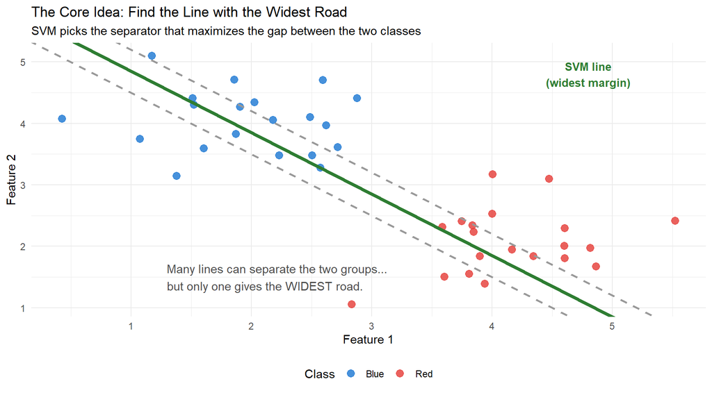

```r
set.seed(MASTER_SEED)

blue <- data.frame(x = rnorm(20, mean = 2, sd = 0.6),
                   y = rnorm(20, mean = 4, sd = 0.6),
                   class = "Blue")
red  <- data.frame(x = rnorm(20, mean = 4, sd = 0.6),
                   y = rnorm(20, mean = 2, sd = 0.6),
                   class = "Red")
demo_df <- rbind(blue, red)

ggplot(demo_df, aes(x = x, y = y, color = class)) +
  geom_point(size = 3, alpha = 0.8) +
  scale_color_manual(values = c("Blue" = "#1976D2", "Red" = "#E53935")) +
  geom_abline(intercept = 6.2, slope = -1, color = "grey60",
              linewidth = 0.8, linetype = "dashed") +
  geom_abline(intercept = 5.5, slope = -1, color = "grey60",
              linewidth = 0.8, linetype = "dashed") +
  geom_abline(intercept = 5.85, slope = -1, color = "#2E7D32",
              linewidth = 1.5) +
  annotate("text", x = 1.3, y = 1.5,
           label = "Many lines can separate the two groups...\nbut only one gives the WIDEST road.",
           color = "grey30", size = 3.8, hjust = 0) +
  annotate("text", x = 4.8, y = 4.8,
           label = "SVM line\n(widest margin)",
           color = "#2E7D32", fontface = "bold", size = 3.5) +
  labs(
    title = "The Core Idea: Find the Line with the Widest Road",
    subtitle = "SVM picks the separator that maximizes the gap between the two classes",
    x = "Feature 1", y = "Feature 2", color = "Class"
  ) +
  theme_minimal() +
  theme(legend.position = "bottom")
```

## 1.2 Key Terminology — Plain English

Before diving into the math, let’s pin down the vocabulary. All the technical terms map to simple ideas:

| Technical Term | Plain English | Analogy |
| --- | --- | --- |
| **Hyperplane** | The dividing line (or surface) between classes | The road’s center line |
| **Margin** | The width of the gap between the closest points of each class | The road’s total width |
| **Support Vectors** | The handful of data points that sit right on the edge of the margin — they “support” the road | The houses closest to the road on either side |
| **Maximum Margin** | Making the road as wide as possible | Building the widest road so neither neighborhood encroaches |
| **C (Cost)** | How strictly we enforce the rule “no points inside the road” | How many zoning violations you tolerate |
| **Kernel** | A mathematical trick that lets the SVM draw curved boundaries | Putting on special glasses that let you see the data differently |

## 1.3 Why a Wide Margin Matters

A wider margin means the model is more confident. If the road is very narrow, even a tiny shift in new data could put a point on the wrong side. A wide margin gives the model breathing room.

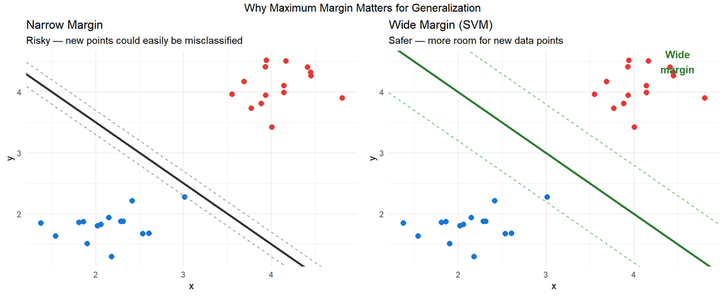

```r
set.seed(MASTER_SEED + 1)

pts <- data.frame(
  x = c(rnorm(15, 2, 0.4), rnorm(15, 4, 0.4)),
  y = c(rnorm(15, 2, 0.4), rnorm(15, 4, 0.4)),
  class = rep(c("A", "B"), each = 15)
)

p_narrow <- ggplot(pts, aes(x, y, color = class)) +
  geom_point(size = 2.5) +
  scale_color_manual(values = c("#1976D2", "#E53935")) +
  geom_abline(intercept = 5.5, slope = -1, linewidth = 1.2, color = "#333333") +
  geom_abline(intercept = 5.3, slope = -1, linetype = "dashed", color = "#999999") +
  geom_abline(intercept = 5.7, slope = -1, linetype = "dashed", color = "#999999") +
  labs(title = "Narrow Margin", subtitle = "Risky — new points could easily be misclassified") +
  theme_minimal() + theme(legend.position = "none")

p_wide <- ggplot(pts, aes(x, y, color = class)) +
  geom_point(size = 2.5) +
  scale_color_manual(values = c("#1976D2", "#E53935")) +
  geom_abline(intercept = 6.0, slope = -1, linewidth = 1.2, color = "#2E7D32") +
  geom_abline(intercept = 5.2, slope = -1, linetype = "dashed", color = "#66BB6A") +
  geom_abline(intercept = 6.8, slope = -1, linetype = "dashed", color = "#66BB6A") +
  annotate("text", x = 4.5, y = 4.5, label = "Wide\nmargin", color = "#2E7D32",
           fontface = "bold", size = 4) +
  labs(title = "Wide Margin (SVM)", subtitle = "Safer — more room for new data points") +
  theme_minimal() + theme(legend.position = "none")

grid.arrange(p_narrow, p_wide, ncol = 2,
  top = "Why Maximum Margin Matters for Generalization")
```

# Part 2: Linear SVM — The Math Behind the Road

## 2.1 The Hyperplane Equation

In two dimensions, a hyperplane is just a straight line described by:

$$w_1 x_1 + w_2 x_2 + b = 0$$

In plain language: **$w$** (the weight vector) determines the direction the line faces, and **$b$** (the bias) shifts it left or right.

- Points on one side satisfy $w_1 x_1 + w_2 x_2 + b > 0$ (class +1)
- Points on the other side satisfy $w_1 x_1 + w_2 x_2 + b < 0$ (class −1)

The margin boundaries are:

$$w_1 x_1 + w_2 x_2 + b = +1 \quad
\text{(positive margin)}$$
$$w_1 x_1 +
w_2 x_2 + b = -1 \quad \text{(negative margin)}$$

The distance between these two lines (the road width) is:

$$\text{Margin} =
\frac{2}{\|w\|}$$

So to make the margin as wide as possible, we need to make $\|w\|$ as **small** as possible — which leads to the SVM optimization problem.

## 2.2 Visualizing the Margin and Support Vectors

Let’s build our first real SVM and see these concepts come alive.

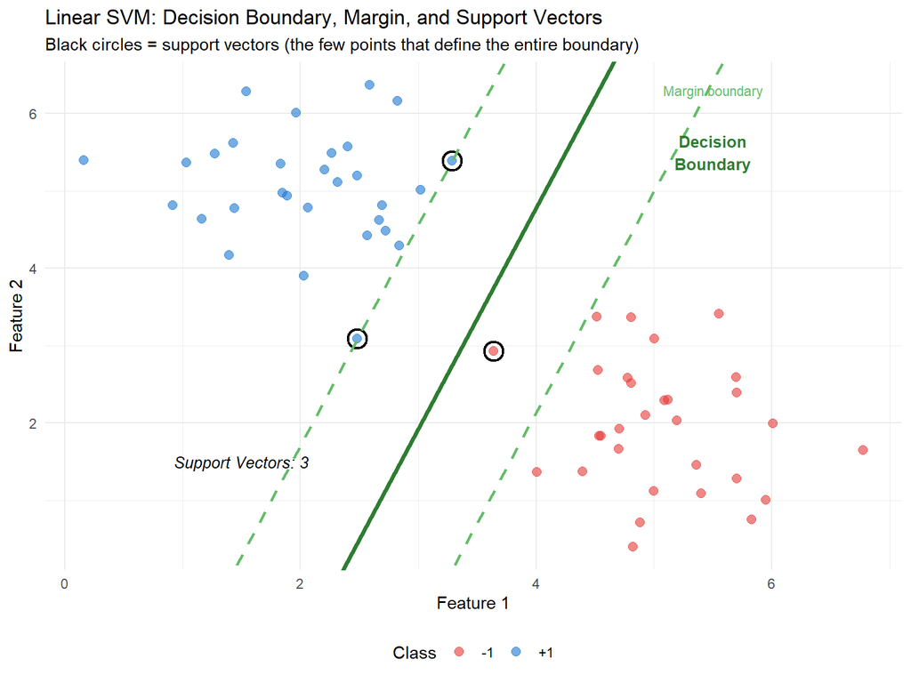

```r
set.seed(MASTER_SEED)

x1 <- c(rnorm(30, 2, 0.7), rnorm(30, 5, 0.7))
x2 <- c(rnorm(30, 5, 0.7), rnorm(30, 2, 0.7))
y  <- factor(c(rep("+1", 30), rep("-1", 30)))
svm_data <- data.frame(x1, x2, y)

svm_lin <- svm(y ~ x1 + x2, data = svm_data, kernel = "linear",
               cost = 1, scale = FALSE)

w  <- t(svm_lin$coefs) %*% svm_lin$SV
b  <- -svm_lin$rho

slope     <- -w[1] / w[2]
intercept <- -b / w[2]
margin_up <- -(b + 1) / w[2]
margin_dn <- -(b - 1) / w[2]

sv_df <- as.data.frame(svm_lin$SV)
sv_df$y <- svm_data$y[svm_lin$index]

ggplot(svm_data, aes(x = x1, y = x2, color = y)) +
  geom_point(size = 2.5, alpha = 0.6) +
  geom_point(data = sv_df, aes(x = x1, y = x2),
             shape = 1, size = 5, stroke = 1.3, color = "black") +
  geom_abline(intercept = intercept, slope = slope,
              color = "#2E7D32", linewidth = 1.3) +
  geom_abline(intercept = margin_up, slope = slope,
              color = "#66BB6A", linewidth = 0.9, linetype = "dashed") +
  geom_abline(intercept = margin_dn, slope = slope,
              color = "#66BB6A", linewidth = 0.9, linetype = "dashed") +
  scale_color_manual(values = c("+1" = "#1976D2", "-1" = "#E53935")) +
  annotate("text", x = 5.5, y = 5.5, label = "Decision\nBoundary",
           color = "#2E7D32", fontface = "bold", size = 3.5) +
  annotate("text", x = 5.5, y = 6.3, label = "Margin boundary",
           color = "#66BB6A", size = 3) +
  annotate("text", x = 1.5, y = 1.5,
           label = paste("Support Vectors:", nrow(sv_df)),
           color = "black", fontface = "italic", size = 3.5) +
  labs(
    title = "Linear SVM: Decision Boundary, Margin, and Support Vectors",
    subtitle = "Black circles = support vectors (the few points that define the entire boundary)",
    x = "Feature 1", y = "Feature 2", color = "Class"
  ) +
  theme_minimal() +
  theme(legend.position = "bottom")
```

> **Key observation:** Out of 60 training points, only a handful are circled as support vectors. These are the only points that matter — if you removed every other point, the SVM would produce the *exact same* boundary. This is what makes SVMs memory-efficient.

## 2.3 Hard-Margin vs. Soft-Margin SVM

### Hard-Margin: No Exceptions Allowed

A **hard-margin** SVM demands that every single data point sits on the correct side of the margin — no violations tolerated. This only works if the data is **perfectly linearly separable** (the two groups don’t overlap at all). In real data, this is almost never the case.

### Soft-Margin: Allow Some Mistakes

A **soft-margin** SVM relaxes the strict rule and allows some points to be inside the margin or even on the wrong side. This is controlled by the **C parameter**:

$$\min_{w,b,\zeta} \frac{1}{2} \|w\|^2 + C
\sum_{i=1}^{n} \zeta_i$$

subject to $y_i(w^T x_i + b) \geq 1 - \zeta_i$ and $\zeta_i \geq 0$.

In plain English:

- The first term ($\frac{1}{2}\|w\|^2$) tries to make the margin **wide**.
- The second term ($C \sum \zeta_i$) penalises **violations** (points inside or across the margin).
- **$C$ is the dial between these two goals:**
  - **Small C** → “Be chill, allow some mistakes, make the road wide” → wider margin, simpler model.
  - **Large C** → “Be strict, punish every mistake” → narrower margin, tries harder to classify every training point correctly.

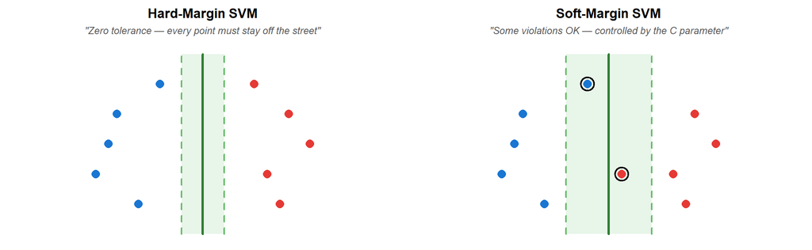

### Why Hard Margins Break: Outlier Sensitivity

Hard-margin SVMs have two fatal flaws that Géron highlights:

> *“First, it only works if the data is linearly separable. Second, it is sensitive to outliers.”* — Géron, ch. 5 **[3]**

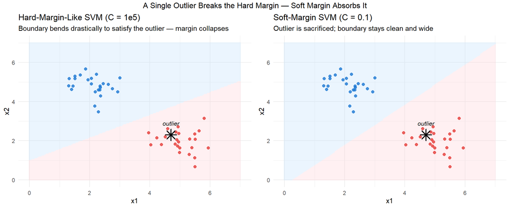

```r
set.seed(MASTER_SEED + 11)

x1_out <- c(rnorm(25, 2, 0.45), rnorm(25, 5, 0.45))
x2_out <- c(rnorm(25, 5, 0.45), rnorm(25, 2, 0.45))
y_out  <- factor(c(rep("A", 25), rep("B", 25)))
df_clean <- data.frame(x1 = x1_out, x2 = x2_out, y = y_out)

# Inject one outlier — a class-A point that sits deep inside the B cloud
df_outlier <- rbind(df_clean,
                    data.frame(x1 = 4.7, x2 = 2.3, y = factor("A", levels = levels(y_out))))

grid_out <- expand.grid(
  x1 = seq(0, 7, length.out = 150),
  x2 = seq(0, 7, length.out = 150)
)

# "Hard-margin-like": very high C punishes every violation
svm_hard <- svm(y ~ x1 + x2, data = df_outlier, kernel = "linear",
                cost = 1e5, scale = FALSE)
# Soft-margin: moderate C lets the outlier be misclassified
svm_soft <- svm(y ~ x1 + x2, data = df_outlier, kernel = "linear",
                cost = 0.1, scale = FALSE)

grid_out$hard <- predict(svm_hard, grid_out)
grid_out$soft <- predict(svm_soft, grid_out)

p_hard <- ggplot() +
  geom_tile(data = grid_out, aes(x = x1, y = x2, fill = hard), alpha = 0.3) +
  geom_point(data = df_outlier, aes(x = x1, y = x2, color = y), size = 2, alpha = 0.8) +
  geom_point(data = df_outlier[nrow(df_outlier), ],
             aes(x = x1, y = x2), shape = 8, size = 5, stroke = 1.3, color = "black") +
  annotate("text", x = 4.7, y = 2.9, label = "outlier",
           color = "black", fontface = "italic", size = 3.3) +
  scale_fill_manual(values = c("A" = "#BBDEFB", "B" = "#FFCDD2"), guide = "none") +
  scale_color_manual(values = c("A" = "#1976D2", "B" = "#E53935"), guide = "none") +
  labs(title = "Hard-Margin-Like SVM (C = 1e5)",
       subtitle = "Boundary bends drastically to satisfy the outlier — margin collapses") +
  theme_minimal()

p_soft <- ggplot() +
  geom_tile(data = grid_out, aes(x = x1, y = x2, fill = soft), alpha = 0.3) +
  geom_point(data = df_outlier, aes(x = x1, y = x2, color = y), size = 2, alpha = 0.8) +
  geom_point(data = df_outlier[nrow(df_outlier), ],
             aes(x = x1, y = x2), shape = 8, size = 5, stroke = 1.3, color = "black") +
  annotate("text", x = 4.7, y = 2.9, label = "outlier",
           color = "black", fontface = "italic", size = 3.3) +
  scale_fill_manual(values = c("A" = "#BBDEFB", "B" = "#FFCDD2"), guide = "none") +
  scale_color_manual(values = c("A" = "#1976D2", "B" = "#E53935"), guide = "none") +
  labs(title = "Soft-Margin SVM (C = 0.1)",
       subtitle = "Outlier is sacrificed; boundary stays clean and wide") +
  theme_minimal()

grid.arrange(p_hard, p_soft, ncol = 2,
  top = "A Single Outlier Breaks the Hard Margin — Soft Margin Absorbs It")
```

> **Takeaway:** Real data is noisy. The soft margin lets you pay a small, controlled price for each misclassified point in exchange for a much more stable decision boundary. This is the ordinary, everyday mode of SVM usage.

## 2.4 The C Parameter: Your Model’s Strictness Dial

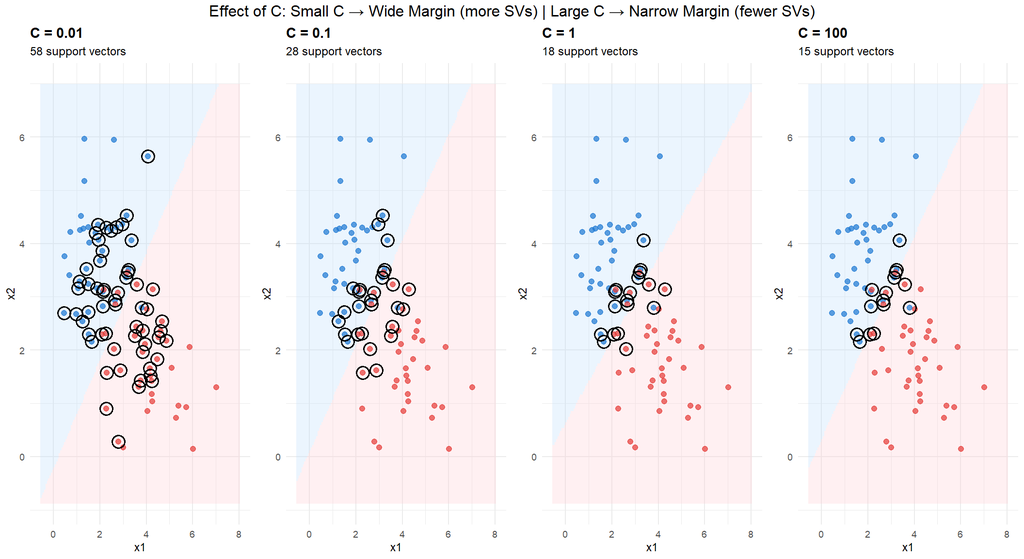

```r
set.seed(MASTER_SEED + 2)

n <- 80
x1_c <- c(rnorm(n/2, 2, 1), rnorm(n/2, 4, 1))
x2_c <- c(rnorm(n/2, 4, 1), rnorm(n/2, 2, 1))
y_c  <- factor(c(rep("A", n/2), rep("B", n/2)))
df_c <- data.frame(x1 = x1_c, x2 = x2_c, y = y_c)

grid_c <- expand.grid(
  x1 = seq(min(x1_c) - 1, max(x1_c) + 1, length.out = 150),
  x2 = seq(min(x2_c) - 1, max(x2_c) + 1, length.out = 150)
)

c_values <- c(0.01, 0.1, 1, 100)

plots_c <- lapply(c_values, function(C_val) {
  m <- svm(y ~ x1 + x2, data = df_c, kernel = "linear", cost = C_val, scale = FALSE)
  grid_c$pred <- predict(m, grid_c)
  n_sv <- nrow(m$SV)

  ggplot() +
    geom_tile(data = grid_c, aes(x = x1, y = x2, fill = pred), alpha = 0.3) +
    geom_point(data = df_c, aes(x = x1, y = x2, color = y), size = 1.8, alpha = 0.7) +
    geom_point(data = as.data.frame(m$SV), aes(x = x1, y = x2),
               shape = 1, size = 4, stroke = 1, color = "black") +
    scale_fill_manual(values = c("A" = "#BBDEFB", "B" = "#FFCDD2"), guide = "none") +
    scale_color_manual(values = c("A" = "#1976D2", "B" = "#E53935"), guide = "none") +
    labs(
      title = sprintf("C = %s", C_val),
      subtitle = sprintf("%d support vectors", n_sv)
    ) +
    theme_minimal(base_size = 9) +
    theme(plot.title = element_text(face = "bold"))
})

do.call(grid.arrange, c(plots_c, ncol = 4,
  top = "Effect of C: Small C → Wide Margin (more SVs) | Large C → Narrow Margin (fewer SVs)"))
```

> **Reading the plots:**
> - **C = 0.01**: Very lenient. Wide margin, many support vectors, ignores some misclassifications.
> - **C = 0.1**: Moderate. A reasonable balance.
> - **C = 1**: The default. Fairly strict.
> - **C = 100**: Very strict. Tries hard to classify every training point — risks overfitting.

## 2.5 The Hinge Loss: How SVM Actually Measures “Violation”

What does the soft-margin SVM charge each mis-behaving point? The answer is the **hinge loss**, which is the loss function baked into every linear SVM. For a training point $(x_i, y_i)$ with label $t_i \in \{-1, +1\}$, the hinge loss is:

$$\mathcal{L}_{\text{hinge}}(t_i, \, w^T
x_i + b) \;=\; \max\!\left(0, \; 1 - t_i \cdot (w^T x_i +
b)\right)$$

Together with the margin-width term, it produces the full linear-SVM cost function **(Géron Eq. 5-13)**:

$$J(w, b) \;=\; \tfrac{1}{2} w^T w \;+\; C
\sum_{i=1}^{m} \max\!\left(0, \; 1 - t_i (w^T x_i +
b)\right)$$

Reading the hinge loss geometrically:

- If a point is **safely past the margin on the correct side** ($t_i \cdot (w^T x_i + b) \geq 1$), the loss is exactly **zero** — the point is ignored.
- If a point sits **inside the margin or on the wrong side**, the loss grows **linearly** with how badly it violates.
- The “hinge” — the kink at 1 — is what gives the loss its name.

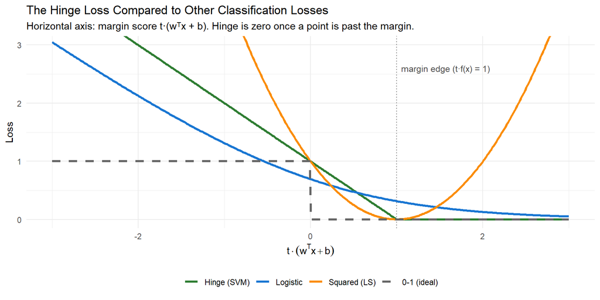

```r
z <- seq(-3, 3, length.out = 400)
hinge  <- pmax(0, 1 - z)
logist <- log(1 + exp(-z))
sq     <- (1 - z)^2
zero_one <- as.numeric(z < 0)

loss_df <- data.frame(
  z = rep(z, 4),
  loss = c(hinge, logist, sq, zero_one),
  type = factor(rep(c("Hinge (SVM)", "Logistic", "Squared (LS)", "0-1 (ideal)"),
                    each = length(z)),
                levels = c("Hinge (SVM)", "Logistic", "Squared (LS)", "0-1 (ideal)"))
)

ggplot(loss_df, aes(x = z, y = loss, color = type, linetype = type)) +
  geom_line(linewidth = 1.2) +
  geom_vline(xintercept = 1, linetype = "dotted", color = "grey40") +
  annotate("text", x = 1.05, y = 2.6, label = "margin edge (t·f(x) = 1)",
           hjust = 0, color = "grey30", size = 3.3) +
  scale_color_manual(values = c(
    "Hinge (SVM)"  = "#2E7D32",
    "Logistic"     = "#1976D2",
    "Squared (LS)" = "#FB8C00",
    "0-1 (ideal)"  = "grey40"
  )) +
  scale_linetype_manual(values = c(
    "Hinge (SVM)"  = "solid",
    "Logistic"     = "solid",
    "Squared (LS)" = "solid",
    "0-1 (ideal)"  = "dashed"
  )) +
  coord_cartesian(ylim = c(0, 3)) +
  labs(
    title = "The Hinge Loss Compared to Other Classification Losses",
    subtitle = "Horizontal axis: margin score t·(wᵀx + b). Hinge is zero once a point is past the margin.",
    x = expression(t %.% (w^T * x + b)),
    y = "Loss",
    color = NULL, linetype = NULL
  ) +
  theme_minimal() +
  theme(legend.position = "bottom")
```

> **Why hinge loss and not squared error?** The hinge loss has a *flat-zero* region — it stops caring about points that are already safely classified. Squared loss, by contrast, keeps pulling the boundary toward every point (including ones that were already correct). That “I only care about points near the edge” behavior is exactly what creates the sparse, support-vector-based solution.

# Part 3: The Kernel Trick — Drawing Curved Boundaries

## 3.1 The Problem: Data That Can’t Be Separated by a Straight Line

Real-world data is rarely neat enough for a straight line. Consider this classic example: one class forms a ring around the other. No straight line can separate them.

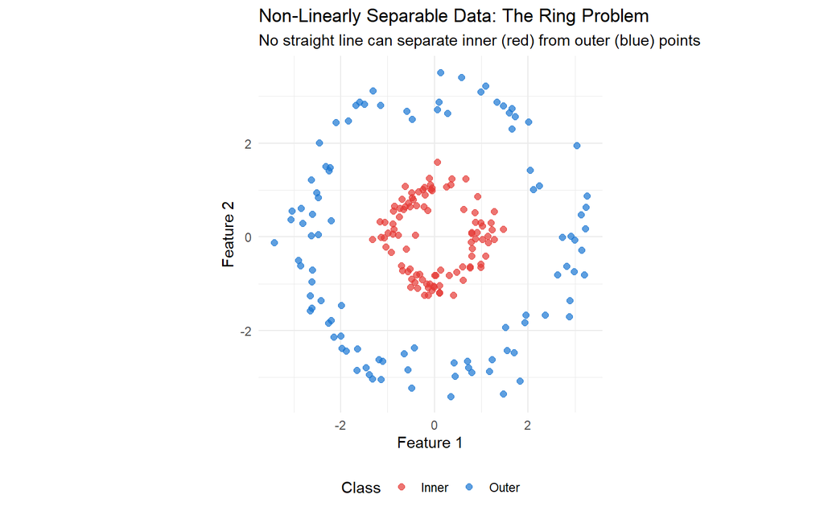

```r
set.seed(MASTER_SEED + 3)

n_ring <- 200
theta  <- runif(n_ring, 0, 2 * pi)
r_inner <- rnorm(n_ring / 2, mean = 1, sd = 0.2)
r_outer <- rnorm(n_ring / 2, mean = 3, sd = 0.3)

ring_data <- data.frame(
  x1 = c(r_inner * cos(theta[1:(n_ring/2)]), r_outer * cos(theta[(n_ring/2+1):n_ring])),
  x2 = c(r_inner * sin(theta[1:(n_ring/2)]), r_outer * sin(theta[(n_ring/2+1):n_ring])),
  y  = factor(c(rep("Inner", n_ring/2), rep("Outer", n_ring/2)))
)

ggplot(ring_data, aes(x = x1, y = x2, color = y)) +
  geom_point(size = 2, alpha = 0.7) +
  scale_color_manual(values = c("Inner" = "#E53935", "Outer" = "#1976D2")) +
  coord_equal() +
  labs(
    title = "Non-Linearly Separable Data: The Ring Problem",
    subtitle = "No straight line can separate inner (red) from outer (blue) points",
    x = "Feature 1", y = "Feature 2", color = "Class"
  ) +
  theme_minimal() +
  theme(legend.position = "bottom")
```

## 3.2 The Kernel Trick: A Magical Transformation

Here is the core insight behind the kernel trick, explained with an analogy:

> **Imagine you’re looking at a crowd from above (a bird’s-eye view).** Red-shirted people form a circle in the middle, surrounded by blue-shirted people. From above, you can’t draw a single straight line to separate them. **Now imagine you could float up in a helicopter** — from that elevated angle, you can see the reds are on a hill and the blues are in the valley. A flat sheet of glass slid between hill and valley separates them perfectly.

That’s what a kernel does mathematically: it **transforms the data into a higher dimension** where a straight separator works. The beauty is that the SVM never actually computes the higher-dimensional coordinates — it only needs the **distances between points** in that new space (the “kernel function”).

### Common Kernels

| Kernel | Formula | What it does |
| --- | --- | --- |
| **Linear** | $K(x, x') = x \cdot x'$ | No transformation — works when data is already linearly separable |
| **Polynomial** | $K(x, x') = (\gamma\, x \cdot x' + r)^d$ | Creates curved boundaries by considering feature interactions up to degree $d$ |
| **RBF (Radial Basis Function)** | $K(x, x') = \exp(-\gamma \\|x - x'\\|^2)$ | Creates smooth, flexible boundaries; the most popular choice for non-linear data |
| **Sigmoid** | $K(x, x') = \tanh(\gamma\, x \cdot x' + r)$ | Behaves like a two-layer neural network; useful historically, rarely a first choice today |

> **Beyond these four**, specialized kernels exist for specific data structures: **string kernels** for text and DNA sequences, **graph kernels** for network data, and **spectrum / subsequence kernels** for bioinformatics. Géron notes that “as a rule of thumb, you should always try the linear kernel first (`LinearSVC` is much faster than `SVC(kernel='linear')`), especially if the training set is very large or if it has plenty of features. If the training set is not too large, you should also try the Gaussian RBF kernel; it works well in most cases.” **[3]**

## 3.3 The Kernel Trick Visualized: Lifting Data into a Higher Dimension

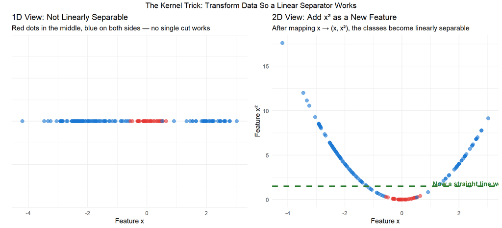

```r
set.seed(MASTER_SEED + 4)
n_kt <- 150
x_1d <- c(rnorm(n_kt/2, -2, 0.6), rnorm(n_kt/4, 0, 0.3), rnorm(n_kt/4, 2, 0.6))
y_1d <- factor(c(rep("B", n_kt/2), rep("A", n_kt/4), rep("B", n_kt/4)))

df_1d <- data.frame(x = x_1d, y = y_1d)

p_1d <- ggplot(df_1d, aes(x = x, y = 0, color = y)) +
  geom_point(size = 2.5, alpha = 0.6) +
  scale_color_manual(values = c("A" = "#E53935", "B" = "#1976D2")) +
  labs(title = "1D View: Not Linearly Separable",
       subtitle = "Red dots in the middle, blue on both sides — no single cut works",
       x = "Feature x", y = "") +
  theme_minimal() + theme(legend.position = "none",
                           axis.text.y = element_blank(),
                           axis.ticks.y = element_blank())

df_2d <- df_1d %>% mutate(x_sq = x^2)

p_2d <- ggplot(df_2d, aes(x = x, y = x_sq, color = y)) +
  geom_point(size = 2.5, alpha = 0.6) +
  scale_color_manual(values = c("A" = "#E53935", "B" = "#1976D2")) +
  geom_hline(yintercept = 1.5, color = "#2E7D32", linewidth = 1.2, linetype = "dashed") +
  annotate("text", x = 2.5, y = 1.8, label = "Now a straight line works!",
           color = "#2E7D32", fontface = "bold", size = 3.5) +
  labs(title = "2D View: Add x² as a New Feature",
       subtitle = "After mapping x → (x, x²), the classes become linearly separable",
       x = "Feature x", y = "Feature x²") +
  theme_minimal() + theme(legend.position = "none")

grid.arrange(p_1d, p_2d, ncol = 2,
  top = "The Kernel Trick: Transform Data So a Linear Separator Works")
```

## 3.4 Similarity Features: The Intuition Behind the RBF Kernel

Before comparing kernels, it helps to understand **why** the RBF kernel works. Géron explains it with a second transformation technique called **similarity features** — a surprisingly concrete idea that leads naturally to the RBF formula.

Pick a few reference points in your data — call them **landmarks**. For every training point, compute *how similar* it is to each landmark using a Gaussian bell curve:

$$\phi_{\gamma}(x, \ell) \;=\;
\exp\!\left(-\gamma \, \lVert x - \ell \rVert^{2}\right)$$

- At the landmark itself, similarity = 1.
- Far from the landmark, similarity ≈ 0.
- $\gamma$ controls how fast similarity decays with distance.

Replace the original features with these **similarity scores**, and suddenly a dataset that was tangled in the original space becomes linearly separable. The RBF kernel is just the “free version” of this trick: the kernel function computes these similarity scores *implicitly* — for every pair of points, with every training instance acting as its own landmark — without ever materializing the new features.

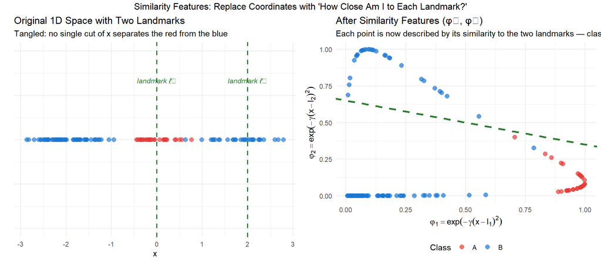

```r
set.seed(MASTER_SEED + 12)

# Build the same 1D example as before
x_land <- c(rnorm(60, -2, 0.55), rnorm(30, 0, 0.3), rnorm(30, 2, 0.55))
y_land <- factor(c(rep("B", 60), rep("A", 30), rep("B", 30)),
                 levels = c("A", "B"))
df_land <- data.frame(x = x_land, y = y_land)

# Two landmarks (Géron Fig 5-8): one in the middle, one on the right
ell1 <- 0      # near the red cluster
ell2 <- 2      # near the right blue cluster
gamma_k <- 0.6

df_land$phi1 <- exp(-gamma_k * (df_land$x - ell1)^2)
df_land$phi2 <- exp(-gamma_k * (df_land$x - ell2)^2)

p_original <- ggplot(df_land, aes(x = x, y = 0, color = y)) +
  geom_point(size = 2.5, alpha = 0.65) +
  geom_vline(xintercept = c(ell1, ell2), linetype = "dashed", color = "#2E7D32",
             linewidth = 0.8) +
  annotate("text", x = ell1, y = 0.4, label = "landmark ℓ₁",
           color = "#2E7D32", size = 3.3, fontface = "italic") +
  annotate("text", x = ell2, y = 0.4, label = "landmark ℓ₂",
           color = "#2E7D32", size = 3.3, fontface = "italic") +
  scale_color_manual(values = c("A" = "#E53935", "B" = "#1976D2")) +
  labs(title = "Original 1D Space with Two Landmarks",
       subtitle = "Tangled: no single cut of x separates the red from the blue",
       x = "x", y = "") +
  coord_cartesian(ylim = c(-0.6, 0.6)) +
  theme_minimal() +
  theme(legend.position = "none",
        axis.text.y = element_blank(),
        axis.ticks.y = element_blank())

p_similarity <- ggplot(df_land, aes(x = phi1, y = phi2, color = y)) +
  geom_point(size = 2.5, alpha = 0.7) +
  geom_abline(intercept = 0.65, slope = -0.3,
              color = "#2E7D32", linewidth = 1.1, linetype = "dashed") +
  scale_color_manual(values = c("A" = "#E53935", "B" = "#1976D2")) +
  labs(title = "After Similarity Features (φ₁, φ₂)",
       subtitle = "Each point is now described by its similarity to the two landmarks — classes separate cleanly",
       x = expression(varphi[1] == exp(-gamma * (x - l[1])^2)),
       y = expression(varphi[2] == exp(-gamma * (x - l[2])^2)),
       color = "Class") +
  theme_minimal() +
  theme(legend.position = "bottom")

grid.arrange(p_original, p_similarity, ncol = 2,
  top = "Similarity Features: Replace Coordinates with 'How Close Am I to Each Landmark?'")
```

> **Key insight:** The RBF kernel $K(x, x') = \exp(-\gamma \lVert x - x'\rVert^2)$ is exactly this similarity measure, applied between **every pair** of training points. Because of the kernel trick, the SVM never has to build the expanded feature matrix explicitly — it just plugs the kernel value into the dual optimization problem.

### Mercer’s Theorem (Why This Works)

Why is any smooth, symmetric similarity function a valid “kernel”? **Mercer’s theorem** guarantees that if $K(a, b)$ satisfies a few mild mathematical conditions (continuous, symmetric, and positive semi-definite), then there exists *some* higher-dimensional feature map $\phi$ such that $K(a, b) = \phi(a)^\top \phi(b)$ — even if we can’t write $\phi$ down explicitly. For the Gaussian RBF kernel, $\phi$ maps each point to an **infinite-dimensional** space — which is precisely why we don’t want to materialize it and why the kernel trick is so valuable **[3]**.

## 3.5 Comparing Kernels on the Ring Dataset

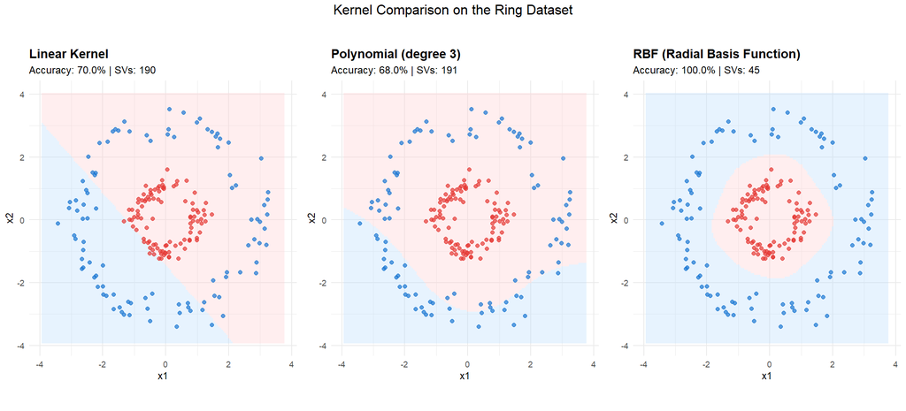

```r
kernels <- list(
  list(kernel = "linear",     name = "Linear Kernel"),
  list(kernel = "polynomial", name = "Polynomial (degree 3)"),
  list(kernel = "radial",     name = "RBF (Radial Basis Function)")
)

grid_ring <- expand.grid(
  x1 = seq(min(ring_data$x1) - 0.5, max(ring_data$x1) + 0.5, length.out = 150),
  x2 = seq(min(ring_data$x2) - 0.5, max(ring_data$x2) + 0.5, length.out = 150)
)

plots_k <- lapply(kernels, function(k) {
  m <- svm(y ~ x1 + x2, data = ring_data, kernel = k$kernel,
           cost = 10, gamma = 1, degree = 3, scale = FALSE)
  grid_ring$pred <- predict(m, grid_ring)
  n_sv <- nrow(m$SV)
  acc <- mean(predict(m, ring_data) == ring_data$y)

  ggplot() +
    geom_tile(data = grid_ring, aes(x = x1, y = x2, fill = pred), alpha = 0.35) +
    geom_point(data = ring_data, aes(x = x1, y = x2, color = y), size = 1.5, alpha = 0.7) +
    scale_fill_manual(values = c("Inner" = "#FFCDD2", "Outer" = "#BBDEFB"), guide = "none") +
    scale_color_manual(values = c("Inner" = "#E53935", "Outer" = "#1976D2"), guide = "none") +
    coord_equal() +
    labs(
      title = k$name,
      subtitle = sprintf("Accuracy: %.1f%% | SVs: %d", acc * 100, n_sv)
    ) +
    theme_minimal(base_size = 9) +
    theme(plot.title = element_text(face = "bold"))
})

do.call(grid.arrange, c(plots_k, ncol = 3,
  top = "Kernel Comparison on the Ring Dataset"))
```

# Part 4: The RBF Kernel — SVM’s Secret Weapon

## 4.1 How RBF Works (Intuition)

The RBF kernel measures how **close** two data points are:

$$K(x, x') = \exp\left(-\gamma \|x -
x'\|^2\right)$$

- When two points are **close together**, $\|x - x'\|^2$ is small, so $K$ is close to 1 (high similarity).
- When two points are **far apart**, $\|x - x'\|^2$ is large, so $K$ is close to 0 (low similarity).

The parameter **$\gamma$** controls how far each point’s influence reaches:

- **Small $\gamma$**: Each point’s influence reaches far → smoother, simpler boundaries.
- **Large $\gamma$**: Each point’s influence is local → more complex, wiggly boundaries.

## 4.2 Visualizing the Gamma Parameter

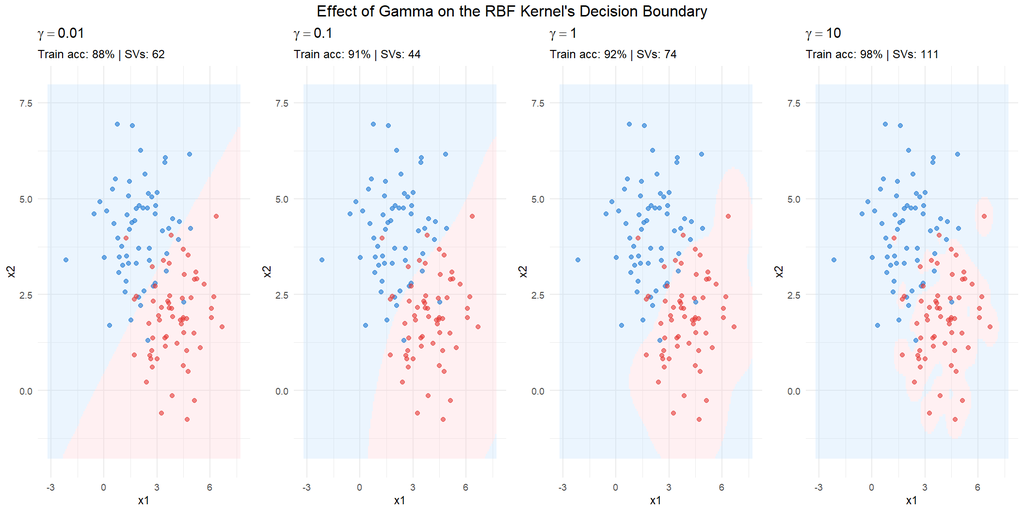

```r
set.seed(MASTER_SEED + 5)

n_g <- 120
x1_g <- c(rnorm(n_g/2, 2, 1.2), rnorm(n_g/2, 4, 1.2))
x2_g <- c(rnorm(n_g/2, 4, 1.2), rnorm(n_g/2, 2, 1.2))
y_g  <- factor(c(rep("A", n_g/2), rep("B", n_g/2)))
df_g <- data.frame(x1 = x1_g, x2 = x2_g, y = y_g)

grid_g <- expand.grid(
  x1 = seq(min(x1_g) - 1, max(x1_g) + 1, length.out = 150),
  x2 = seq(min(x2_g) - 1, max(x2_g) + 1, length.out = 150)
)

gamma_vals <- c(0.01, 0.1, 1, 10)

plots_g <- lapply(gamma_vals, function(gv) {
  m <- svm(y ~ x1 + x2, data = df_g, kernel = "radial",
           cost = 1, gamma = gv, scale = FALSE)
  grid_g$pred <- predict(m, grid_g)
  n_sv <- nrow(m$SV)
  acc <- mean(predict(m, df_g) == df_g$y)

  ggplot() +
    geom_tile(data = grid_g, aes(x = x1, y = x2, fill = pred), alpha = 0.3) +
    geom_point(data = df_g, aes(x = x1, y = x2, color = y), size = 1.5, alpha = 0.6) +
    scale_fill_manual(values = c("A" = "#BBDEFB", "B" = "#FFCDD2"), guide = "none") +
    scale_color_manual(values = c("A" = "#1976D2", "B" = "#E53935"), guide = "none") +
    labs(
      title = bquote(gamma == .(gv)),
      subtitle = sprintf("Train acc: %.0f%% | SVs: %d", acc * 100, n_sv)
    ) +
    theme_minimal(base_size = 9) +
    theme(plot.title = element_text(face = "bold"))
})

do.call(grid.arrange, c(plots_g, ncol = 4,
  top = "Effect of Gamma on the RBF Kernel's Decision Boundary"))
```

> - $\gamma = 0.01$: Very smooth, almost linear — underfitting.
> - $\gamma = 0.1$: Good balance — captures the general pattern.
> - $\gamma = 1$: Starting to overfit — the boundary gets wiggly.
> - $\gamma = 10$: Severe overfitting — the boundary wraps tightly around individual points.

## 4.3 The C × Gamma Interaction

Both C and $\gamma$ affect the model’s complexity. Tuning them together is essential.

[figure not shown]

```r
set.seed(MASTER_SEED + 6)

cg_combos <- expand.grid(C = c(0.1, 1, 10), gamma = c(0.1, 1, 10))

plots_cg <- lapply(1:nrow(cg_combos), function(i) {
  C_val <- cg_combos$C[i]
  g_val <- cg_combos$gamma[i]

  m <- svm(y ~ x1 + x2, data = df_g, kernel = "radial",
           cost = C_val, gamma = g_val, scale = FALSE)
  grid_g$pred <- predict(m, grid_g)
  acc <- mean(predict(m, df_g) == df_g$y)

  ggplot() +
    geom_tile(data = grid_g, aes(x = x1, y = x2, fill = pred), alpha = 0.3) +
    geom_point(data = df_g, aes(x = x1, y = x2, color = y), size = 1.2, alpha = 0.5) +
    scale_fill_manual(values = c("A" = "#BBDEFB", "B" = "#FFCDD2"), guide = "none") +
    scale_color_manual(values = c("A" = "#1976D2", "B" = "#E53935"), guide = "none") +
    labs(title = sprintf("C=%s, γ=%s", C_val, g_val),
         subtitle = sprintf("Acc: %.0f%%", acc * 100)) +
    theme_minimal(base_size = 8) +
    theme(plot.title = element_text(face = "bold", size = 9))
})

do.call(grid.arrange, c(plots_cg, ncol = 3,
  top = "C × Gamma Grid: How the Two Hyperparameters Interact\n(Rows: increasing C; Columns: increasing Gamma)"))
```

> **Rule of thumb:** Start with `C = 1` and `gamma = 1/ncol(X)` (the default in `e1071`), then use grid search or cross-validation to find the best combination.

# Part 5: Building SVMs in R

## 5.1 SVM on the Iris Dataset

Let’s apply SVM to the classic Iris dataset and compare it with the Decision Tree and Random Forest we built in previous weeks.

```r
data(iris)
set.seed(MASTER_SEED)
train_idx <- sample(1:nrow(iris), floor(0.7 * nrow(iris)))
iris_train <- iris[train_idx, ]
iris_test  <- iris[-train_idx, ]
```

```r
svm_iris <- svm(Species ~ ., data = iris_train, kernel = "radial",
                cost = 1, gamma = 0.25, scale = TRUE)
print(svm_iris)
```

```
##
## Call:
## svm(formula = Species ~ ., data = iris_train, kernel = "radial",
##     cost = 1, gamma = 0.25, scale = TRUE)
##
##
## Parameters:
##    SVM-Type:  C-classification
##  SVM-Kernel:  radial
##        cost:  1
##
## Number of Support Vectors:  46
```

```r
pred_iris <- predict(svm_iris, iris_test)
acc_iris  <- mean(pred_iris == iris_test$Species)

cat(sprintf("SVM Test Accuracy: %.1f%%\n", acc_iris * 100))
```

```
## SVM Test Accuracy: 97.8%
```

```r
table(Predicted = pred_iris, Actual = iris_test$Species)
```

```
##             Actual
## Predicted    setosa versicolor virginica
##   setosa         16          0         0
##   versicolor      0         14         0
##   virginica       0          1        14
```

## 5.2 Decision Boundary on Iris (Petal Features)

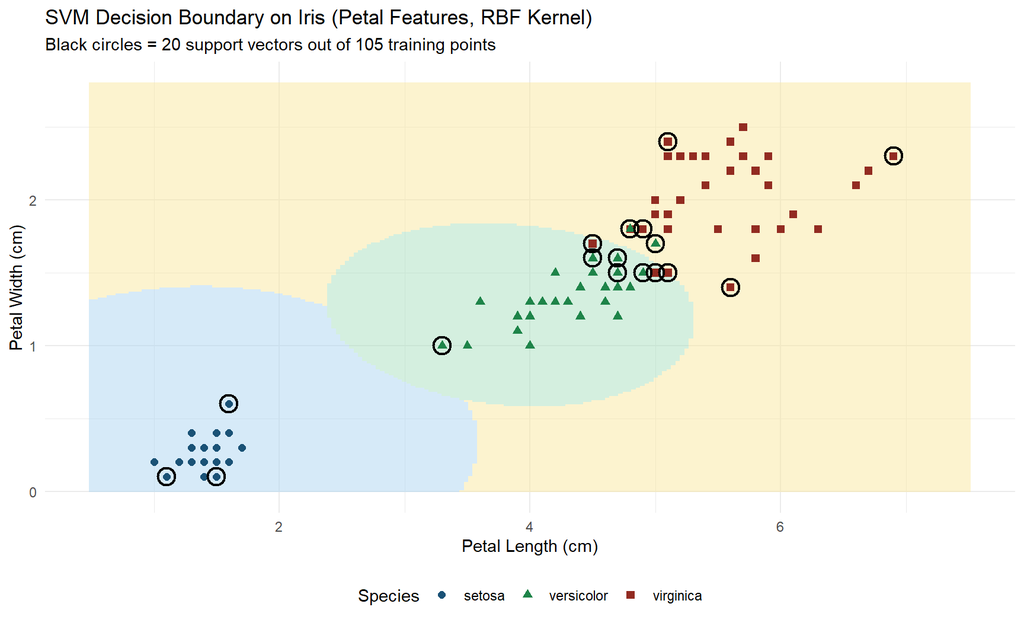

```r
iris_2d <- iris[, c("Petal.Length", "Petal.Width", "Species")]
train_2d <- iris_2d[train_idx, ]
test_2d  <- iris_2d[-train_idx, ]

svm_2d <- svm(Species ~ ., data = train_2d, kernel = "radial",
              cost = 5, gamma = 1, scale = TRUE)

grid_iris <- expand.grid(
  Petal.Length = seq(0.5, 7.5, length.out = 200),
  Petal.Width  = seq(0, 2.8, length.out = 200)
)

scaled_grid <- grid_iris
scaled_grid$Petal.Length <- (grid_iris$Petal.Length - mean(train_2d$Petal.Length)) / sd(train_2d$Petal.Length)
scaled_grid$Petal.Width  <- (grid_iris$Petal.Width  - mean(train_2d$Petal.Width))  / sd(train_2d$Petal.Width)

grid_iris$pred <- predict(svm_2d, grid_iris)

sv_indices <- svm_2d$index
sv_points <- train_2d[sv_indices, ]

palette_iris <- c(setosa = "#AED6F1", versicolor = "#A9DFBF", virginica = "#F9E79F")
point_colors <- c(setosa = "#1A5276", versicolor = "#1E8449", virginica = "#922B21")

ggplot() +
  geom_tile(data = grid_iris,
            aes(x = Petal.Length, y = Petal.Width, fill = pred), alpha = 0.5) +
  geom_point(data = train_2d,
             aes(x = Petal.Length, y = Petal.Width, color = Species, shape = Species),
             size = 2) +
  geom_point(data = sv_points,
             aes(x = Petal.Length, y = Petal.Width),
             shape = 1, size = 4.5, stroke = 1.2, color = "black") +
  scale_fill_manual(values = palette_iris, guide = "none") +
  scale_color_manual(values = point_colors) +
  labs(
    title = "SVM Decision Boundary on Iris (Petal Features, RBF Kernel)",
    subtitle = sprintf("Black circles = %d support vectors out of %d training points",
                       nrow(sv_points), nrow(train_2d)),
    x = "Petal Length (cm)", y = "Petal Width (cm)", color = "Species"
  ) +
  theme_minimal() +
  theme(legend.position = "bottom")
```

> **Compare with Week 02 (Decision Tree) and Week 03 (Random Forest):** The Decision Tree produced rigid, axis-aligned rectangular regions. The Random Forest smoothed those rectangles by averaging many trees. The SVM with an RBF kernel creates **smooth, curved** boundaries that naturally follow the shape of the data.

## 5.3 Hyperparameter Tuning with Cross-Validation

The `e1071` package provides `tune()` for automated grid search with cross-validation.

```r
set.seed(MASTER_SEED)

tune_result <- tune(svm, Species ~ ., data = iris_train,
  kernel = "radial",
  ranges = list(
    cost  = c(0.1, 1, 10, 100),
    gamma = c(0.01, 0.1, 0.5, 1, 2)
  ),
  tunecontrol = tune.control(cross = 5)
)

cat("Best parameters found:\n")
```

```
## Best parameters found:
```

```r
cat(sprintf("  C     = %s\n", tune_result$best.parameters$cost))
```

```
##   C     = 100
```

```r
cat(sprintf("  gamma = %s\n", tune_result$best.parameters$gamma))
```

```
##   gamma = 0.01
```

```r
cat(sprintf("  CV error = %.4f\n", tune_result$best.performance))
```

```
##   CV error = 0.0381
```

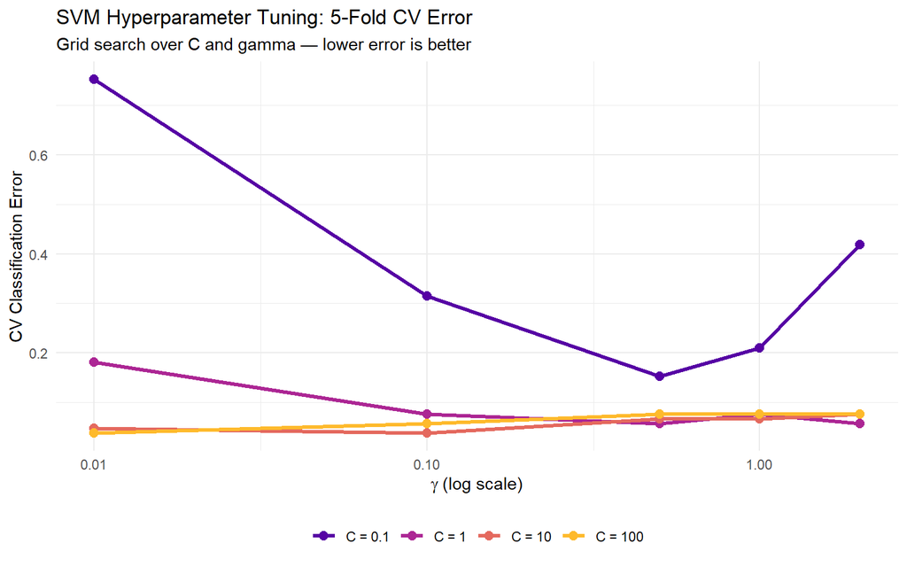

```r
tune_df <- tune_result$performances
tune_df$cost_label <- factor(paste("C =", tune_df$cost))

ggplot(tune_df, aes(x = gamma, y = error, color = cost_label)) +
  geom_line(linewidth = 1.1) +
  geom_point(size = 2.5) +
  scale_x_log10() +
  scale_color_viridis_d(option = "plasma", begin = 0.15, end = 0.85) +
  labs(
    title = "SVM Hyperparameter Tuning: 5-Fold CV Error",
    subtitle = "Grid search over C and gamma — lower error is better",
    x = expression(gamma ~ "(log scale)"), y = "CV Classification Error",
    color = NULL
  ) +
  theme_minimal() +
  theme(legend.position = "bottom")
```

```r
best_svm <- tune_result$best.model
pred_best <- predict(best_svm, iris_test)
acc_best  <- mean(pred_best == iris_test$Species)

cat(sprintf("\nBest SVM Test Accuracy: %.1f%%\n", acc_best * 100))
```

```
##
## Best SVM Test Accuracy: 97.8%
```

```r
table(Predicted = pred_best, Actual = iris_test$Species)
```

```
##             Actual
## Predicted    setosa versicolor virginica
##   setosa         16          0         0
##   versicolor      0         14         0
##   virginica       0          1        14
```

# Part 6: Feature Scaling — Why It’s Critical for SVM

## 6.1 SVMs Are Not Scale Invariant

Unlike Decision Trees and Random Forests, SVMs rely on **distances** between data points. If one feature ranges from 0 to 1 and another from 0 to 10,000, the second feature will completely dominate the distance calculations, and the first feature will be effectively ignored.

**This is the single most common mistake beginners make with SVMs.**

> *“Support Vector Machine algorithms are not scale invariant, so it is highly recommended to scale your data.”* — scikit-learn documentation **[1]**

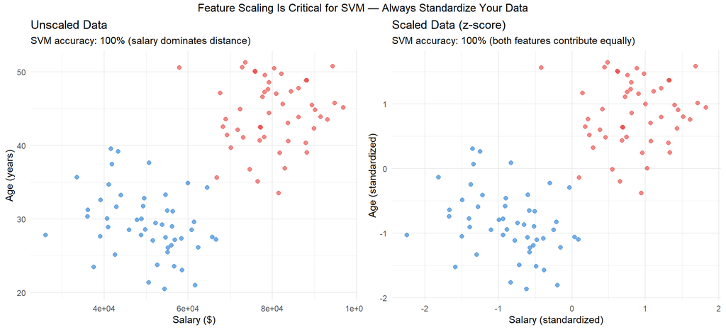

```r
set.seed(MASTER_SEED + 7)

n_sc <- 100
df_unscaled <- data.frame(
  salary   = c(rnorm(n_sc/2, 50000, 8000), rnorm(n_sc/2, 80000, 8000)),
  age      = c(rnorm(n_sc/2, 30, 5), rnorm(n_sc/2, 45, 5)),
  promoted = factor(c(rep("No", n_sc/2), rep("Yes", n_sc/2)))
)

svm_unscaled <- svm(promoted ~ salary + age, data = df_unscaled,
                    kernel = "radial", cost = 1, scale = FALSE)
acc_unscaled <- mean(predict(svm_unscaled, df_unscaled) == df_unscaled$promoted)

svm_scaled <- svm(promoted ~ salary + age, data = df_unscaled,
                  kernel = "radial", cost = 1, scale = TRUE)
acc_scaled <- mean(predict(svm_scaled, df_unscaled) == df_unscaled$promoted)

p_unsc <- ggplot(df_unscaled, aes(x = salary, y = age, color = promoted)) +
  geom_point(size = 2, alpha = 0.6) +
  scale_color_manual(values = c("No" = "#1976D2", "Yes" = "#E53935")) +
  labs(title = "Unscaled Data",
       subtitle = sprintf("SVM accuracy: %.0f%% (salary dominates distance)", acc_unscaled * 100),
       x = "Salary ($)", y = "Age (years)") +
  theme_minimal() + theme(legend.position = "none")

df_sc <- df_unscaled %>%
  mutate(salary_sc = scale(salary), age_sc = scale(age))

p_sc <- ggplot(df_sc, aes(x = salary_sc, y = age_sc, color = df_unscaled$promoted)) +
  geom_point(size = 2, alpha = 0.6) +
  scale_color_manual(values = c("No" = "#1976D2", "Yes" = "#E53935")) +
  labs(title = "Scaled Data (z-score)",
       subtitle = sprintf("SVM accuracy: %.0f%% (both features contribute equally)", acc_scaled * 100),
       x = "Salary (standardized)", y = "Age (standardized)") +
  theme_minimal() + theme(legend.position = "none")

grid.arrange(p_unsc, p_sc, ncol = 2,
  top = "Feature Scaling Is Critical for SVM — Always Standardize Your Data")
```

> **Takeaway:** Always set `scale = TRUE` in `e1071::svm()` (this is the default), or manually standardize your features to zero mean and unit variance before fitting.

# Part 7: SVM for Regression (SVR)

## 7.1 From Classification to Regression

SVMs are versatile: the same street-fitting idea also drives **Support Vector Regression (SVR)**. As Géron puts it, the trick is to **reverse the objective**:

> *“Instead of trying to fit the largest possible street between two classes while limiting margin violations, SVM Regression tries to fit as many instances as possible **on** the street while limiting margin violations (i.e., instances off the street). The width of the street is controlled by a hyperparameter, ε.”* — Géron, *Hands-On Machine Learning*, ch. 5 **[3]**

The street here is a **tube** of half-width $\varepsilon$ (epsilon) drawn around the regression curve. Any point that lands **inside** the tube contributes zero error — the model is said to be $\varepsilon$-**insensitive**. Only points **outside** the tube are penalized. Compare this to ordinary regression:

- **Linear Regression**: Minimize the error for *every* point, no matter how small.
- **SVR**: Ignore small errors (points inside the $\varepsilon$-tube), only penalize the ones that stick out.

Because the model only “sees” the points on the edge of or outside the tube, SVR is naturally robust to noise — small wiggles in the data do not pull the fit around.

## 7.2 Visualizing the Epsilon Tube

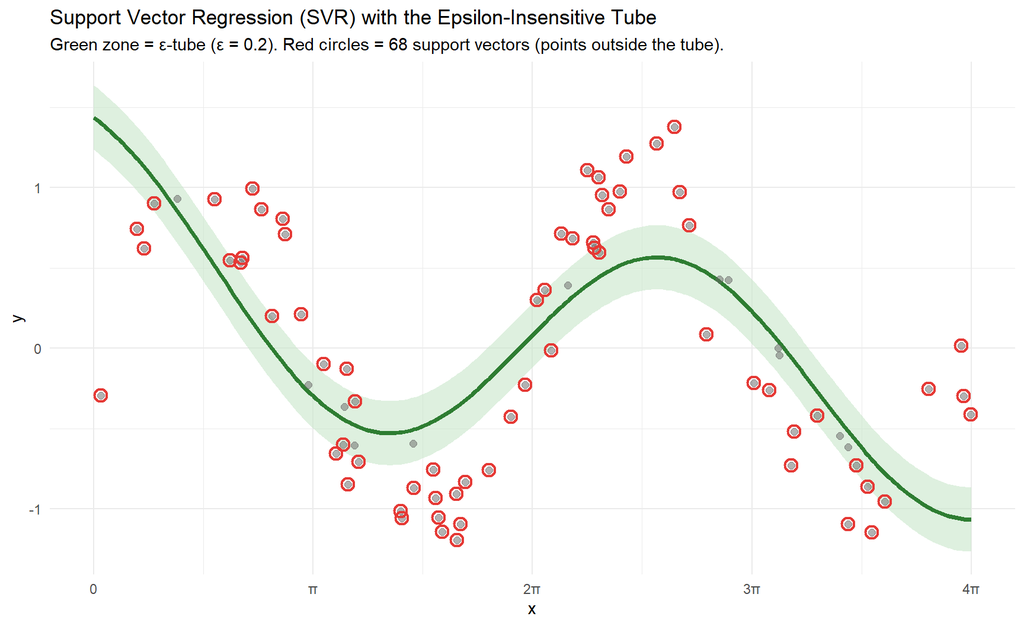

```r
set.seed(MASTER_SEED + 8)

x_svr <- sort(runif(80, 0, 4 * pi))
y_svr <- sin(x_svr) + rnorm(80, sd = 0.25)
df_svr <- data.frame(x = x_svr, y = y_svr)

svr_model <- svm(y ~ x, data = df_svr, type = "eps-regression",
                 kernel = "radial", epsilon = 0.2, cost = 10, gamma = 0.3)

pred_grid <- data.frame(x = seq(0, 4 * pi, length.out = 300))
pred_grid$y_hat <- predict(svr_model, pred_grid)

sv_idx <- svr_model$index
sv_df  <- df_svr[sv_idx, ]

ggplot(df_svr, aes(x = x, y = y)) +
  geom_ribbon(data = pred_grid,
              aes(x = x, ymin = y_hat - svr_model$epsilon,
                  ymax = y_hat + svr_model$epsilon, y = NULL),
              fill = "#C8E6C9", alpha = 0.6) +
  geom_line(data = pred_grid, aes(x = x, y = y_hat),
            color = "#2E7D32", linewidth = 1.3) +
  geom_point(alpha = 0.5, color = "grey40", size = 2) +
  geom_point(data = sv_df, color = "#E53935", size = 3, shape = 1, stroke = 1.2) +
  scale_x_continuous(breaks = c(0, pi, 2*pi, 3*pi, 4*pi),
                     labels = c("0", "π", "2π", "3π", "4π")) +
  labs(
    title = "Support Vector Regression (SVR) with the Epsilon-Insensitive Tube",
    subtitle = sprintf("Green zone = ε-tube (ε = %.1f). Red circles = %d support vectors (points outside the tube).",
                       svr_model$epsilon, length(sv_idx)),
    x = "x", y = "y"
  ) +
  theme_minimal()
```

> Points **inside** the green tube are “close enough” — they incur zero loss. Only the red-circled **support vectors** (points on the edge or outside the tube) influence the model. This makes SVR robust to noise.

## 7.3 Comparing SVR Kernels

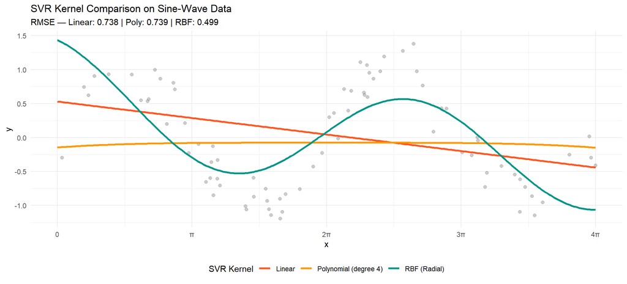

```r
svr_lin <- svm(y ~ x, data = df_svr, type = "eps-regression",
               kernel = "linear", epsilon = 0.2, cost = 5)
svr_poly <- svm(y ~ x, data = df_svr, type = "eps-regression",
                kernel = "polynomial", epsilon = 0.2, cost = 5, degree = 4, gamma = 0.1)
svr_rbf <- svm(y ~ x, data = df_svr, type = "eps-regression",
               kernel = "radial", epsilon = 0.2, cost = 10, gamma = 0.3)

pred_grid$lin  <- predict(svr_lin,  pred_grid)
pred_grid$poly <- predict(svr_poly, pred_grid)
pred_grid$rbf  <- predict(svr_rbf,  pred_grid)

pred_long <- pred_grid %>%
  select(x, lin, poly, rbf) %>%
  pivot_longer(-x, names_to = "kernel", values_to = "pred") %>%
  mutate(kernel = recode(kernel,
    lin  = "Linear",
    poly = "Polynomial (degree 4)",
    rbf  = "RBF (Radial)"
  ))

rmse_fn <- function(actual, predicted) sqrt(mean((actual - predicted)^2))
rmse_lin  <- rmse_fn(df_svr$y, predict(svr_lin,  df_svr))
rmse_poly <- rmse_fn(df_svr$y, predict(svr_poly, df_svr))
rmse_rbf  <- rmse_fn(df_svr$y, predict(svr_rbf,  df_svr))

ggplot(df_svr, aes(x = x, y = y)) +
  geom_point(alpha = 0.4, color = "grey50", size = 1.8) +
  geom_line(data = pred_long, aes(x = x, y = pred, color = kernel), linewidth = 1.2) +
  scale_color_manual(values = c(
    "Linear"                = "#FF5722",
    "Polynomial (degree 4)" = "#FF9800",
    "RBF (Radial)"          = "#009688"
  )) +
  scale_x_continuous(breaks = c(0, pi, 2*pi, 3*pi, 4*pi),
                     labels = c("0", "π", "2π", "3π", "4π")) +
  labs(
    title = "SVR Kernel Comparison on Sine-Wave Data",
    subtitle = sprintf("RMSE — Linear: %.3f | Poly: %.3f | RBF: %.3f",
                       rmse_lin, rmse_poly, rmse_rbf),
    x = "x", y = "y", color = "SVR Kernel"
  ) +
  theme_minimal() +
  theme(legend.position = "bottom")
```

# Part 8: SVM vs. Other Models — A Visual Comparison

```r
set.seed(MASTER_SEED + 9)

n_comp <- 200
x1_comp <- c(rnorm(n_comp/2, 2, 1.3), rnorm(n_comp/2, 4.5, 1.3))
x2_comp <- c(rnorm(n_comp/2, 4.5, 1.3), rnorm(n_comp/2, 2, 1.3))
y_comp  <- factor(c(rep("A", n_comp/2), rep("B", n_comp/2)))
df_comp <- data.frame(x1 = x1_comp, x2 = x2_comp, y = y_comp)

idx_comp <- sample(1:n_comp, floor(0.7 * n_comp))
train_comp <- df_comp[idx_comp, ]
test_comp  <- df_comp[-idx_comp, ]

grid_comp <- expand.grid(
  x1 = seq(min(x1_comp) - 1, max(x1_comp) + 1, length.out = 150),
  x2 = seq(min(x2_comp) - 1, max(x2_comp) + 1, length.out = 150)
)
```

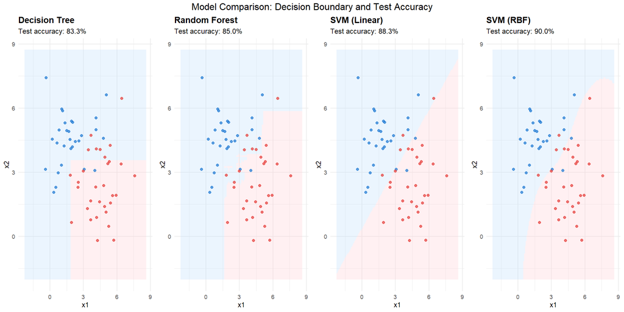

Test accuracy on the 2D classification task

| Model | Test Accuracy (%) |
| --- | --- |
| Decision Tree | 83.3 |
| Random Forest | 85.0 |
| SVM (Linear) | 88.3 |
| SVM (RBF) | 90.0 |

```r
library(rpart)
library(randomForest)

dt_comp <- rpart(y ~ x1 + x2, data = train_comp, method = "class",
                 control = rpart.control(maxdepth = 4))
rf_comp <- randomForest(y ~ x1 + x2, data = train_comp, ntree = 200)
svm_lin_comp <- svm(y ~ x1 + x2, data = train_comp, kernel = "linear", cost = 1, scale = TRUE)
svm_rbf_comp <- svm(y ~ x1 + x2, data = train_comp, kernel = "radial", cost = 5, gamma = 0.5, scale = TRUE)

models_comp <- list(
  list(model = dt_comp,       name = "Decision Tree",    pred_fn = function(m, d) predict(m, d, type = "class")),
  list(model = rf_comp,       name = "Random Forest",    pred_fn = function(m, d) predict(m, d)),
  list(model = svm_lin_comp,  name = "SVM (Linear)",     pred_fn = function(m, d) predict(m, d)),
  list(model = svm_rbf_comp,  name = "SVM (RBF)",        pred_fn = function(m, d) predict(m, d))
)

plots_comp <- lapply(models_comp, function(item) {
  grid_comp$pred <- item$pred_fn(item$model, grid_comp)
  test_pred <- item$pred_fn(item$model, test_comp)
  test_acc  <- mean(test_pred == test_comp$y)

  ggplot() +
    geom_tile(data = grid_comp, aes(x = x1, y = x2, fill = pred), alpha = 0.3) +
    geom_point(data = test_comp, aes(x = x1, y = x2, color = y), size = 1.5, alpha = 0.7) +
    scale_fill_manual(values = c("A" = "#BBDEFB", "B" = "#FFCDD2"), guide = "none") +
    scale_color_manual(values = c("A" = "#1976D2", "B" = "#E53935"), guide = "none") +
    labs(
      title = item$name,
      subtitle = sprintf("Test accuracy: %.1f%%", test_acc * 100)
    ) +
    theme_minimal(base_size = 9) +
    theme(plot.title = element_text(face = "bold"))
})

do.call(grid.arrange, c(plots_comp, ncol = 4,
  top = "Model Comparison: Decision Boundary and Test Accuracy"))
```

# Part 9: Advantages, Disadvantages & Practical Tips

## 9.1 When to Use SVM

SVM Strengths and Weaknesses

| Property | SVM Assessment |
| --- | --- |
| High-dimensional data | Excellent — SVMs work well even when features outnumber samples |
| Small-to-medium datasets | Excellent — SVM is one of the best performers on small data |
| Non-linear patterns | Excellent — the kernel trick handles complex boundaries |
| Memory efficiency | Good — only support vectors are stored, not the entire dataset |
| Outlier robustness | Good (soft margin) — C parameter controls sensitivity to outliers |
| Large datasets (> 100K rows) | Poor — training is O(n² to n³); use Linear SVM or other methods instead |
| Feature scaling required | Required — always standardize features before using SVM |
| Probability estimates | Not native — requires expensive calibration (Platt scaling) |
| Interpretability | Low — the model is a ‘black box’; hard to explain individual predictions |
| Hyperparameter sensitivity | Moderate — C and gamma must be tuned carefully via cross-validation |

## 9.2 Decision Guide: When to Choose SVM

| Scenario | Recommendation |
| --- | --- |
| Small dataset, complex boundary | **SVM (RBF kernel)** — it excels here |
| Need interpretability | Decision Tree or Logistic Regression — SVM is a black box |
| Very large dataset (millions of rows) | Random Forest or Gradient Boosting — SVM is too slow |
| High-dimensional sparse data (e.g., text) | **Linear SVM** — fast and effective |
| Need probability estimates | Random Forest or Logistic Regression — SVM probabilities are unreliable |
| Baseline model with no tuning | Random Forest — SVM needs careful tuning of C and $\gamma$ |

## 9.3 Computational Complexity — When SVMs Get Slow

One of the most important practical facts about SVMs is how their training time scales with the dataset. Géron **[3]** summarizes the picture for Scikit-Learn’s SVM classes — the same tradeoffs apply to R’s `e1071::svm()` (based on `libsvm`) and `kernlab::ksvm()`:

Training-time complexity for common SVM implementations — m = #instances, n = #features

| Class (R / Python) | Time Complexity | Kernel Trick? | Best For |
| --- | --- | --- | --- |
| `e1071::svm()` / Scikit-learn `SVC` | $O(m^{2} n)$ to $O(m^{3} n)$ | Yes | Small-to-medium datasets with complex non-linear boundaries |
| `kernlab::ksvm()` | $O(m^{2} n)$ to $O(m^{3} n)$ | Yes | Same as above, plus extra kernel options and more efficient solvers |
| Scikit-learn `LinearSVC` / `LiblineaR` in R | $O(m \cdot n)$ | No — linear only | Very large datasets or very high-dimensional sparse data (text, gene expression) |
| Scikit-learn `SGDClassifier` (hinge loss) | $O(m \cdot n)$ | No — linear only | Online / streaming data, or datasets too large to fit in memory |

> **The practical implication:** Kernelized SVMs (the ones that use `"radial"`, `"polynomial"`, etc.) have cost that grows **between quadratically and cubically** with the number of training samples. They become “dreadfully slow” (Géron’s words) on datasets with hundreds of thousands of instances. Above that scale, switch to a linear SVM, Random Forest, Gradient Boosting, or a neural network.

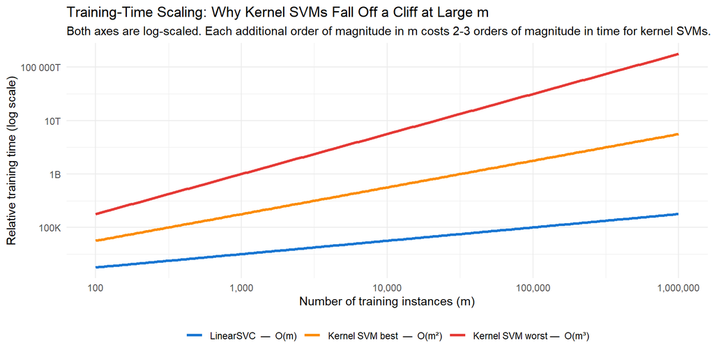

```r
m_grid <- 10 ^ seq(2, 6, length.out = 200)   # 100 to 1,000,000 instances

complexity_df <- data.frame(
  m = rep(m_grid, 3),
  time = c(
    m_grid,              # O(m)       — LinearSVC
    m_grid ^ 2,          # O(m^2)     — kernelized, best case
    m_grid ^ 3           # O(m^3)     — kernelized, worst case
  ),
  algorithm = factor(rep(
    c("LinearSVC  —  O(m)",
      "Kernel SVM best  —  O(m²)",
      "Kernel SVM worst —  O(m³)"),
    each = length(m_grid)),
    levels = c("LinearSVC  —  O(m)",
               "Kernel SVM best  —  O(m²)",
               "Kernel SVM worst —  O(m³)"))
)

ggplot(complexity_df, aes(x = m, y = time, color = algorithm)) +
  geom_line(linewidth = 1.2) +
  scale_x_log10(labels = scales::comma) +
  scale_y_log10(labels = scales::label_number(scale_cut = scales::cut_short_scale())) +
  scale_color_manual(values = c("#1976D2", "#FB8C00", "#E53935")) +
  labs(
    title = "Training-Time Scaling: Why Kernel SVMs Fall Off a Cliff at Large m",
    subtitle = "Both axes are log-scaled. Each additional order of magnitude in m costs 2-3 orders of magnitude in time for kernel SVMs.",
    x = "Number of training instances (m)",
    y = "Relative training time (log scale)",
    color = NULL
  ) +
  theme_minimal() +
  theme(legend.position = "bottom")
```

## 9.4 Practical Tips

1. **Always scale your features** — standardize to zero mean and unit variance.
2. **Start with `kernel = "radial"`** — it’s the most flexible and a good default.
3. **Use `tune()` or `caret::train()`** for systematic hyperparameter search.
4. **Try a wide range** — search C in $\{0.01, 0.1, 1, 10, 100\}$ and $\gamma$ in $\{0.001, 0.01, 0.1, 1\}$ on log scales.
5. **Check the number of support vectors** — if nearly all points are support vectors, the model may be underfitting (try increasing C or $\gamma$).
6. **For large datasets**, consider `kernlab::ksvm()` which offers more efficient solvers and additional kernel options.

# Part 10: Multi-Class SVM

SVMs are inherently binary classifiers (they separate two classes). To handle multiple classes (like the 3-species Iris problem), two strategies are used:

| Strategy | How it works | Number of models |
| --- | --- | --- |
| **One-vs-One (OVO)** | Train one SVM for every pair of classes, then vote | $\frac{k(k-1)}{2}$ |
| **One-vs-All (OVA)** | Train one SVM per class (that class vs. all others) | $k$ |

R’s `e1071::svm()` uses **One-vs-One** by default.

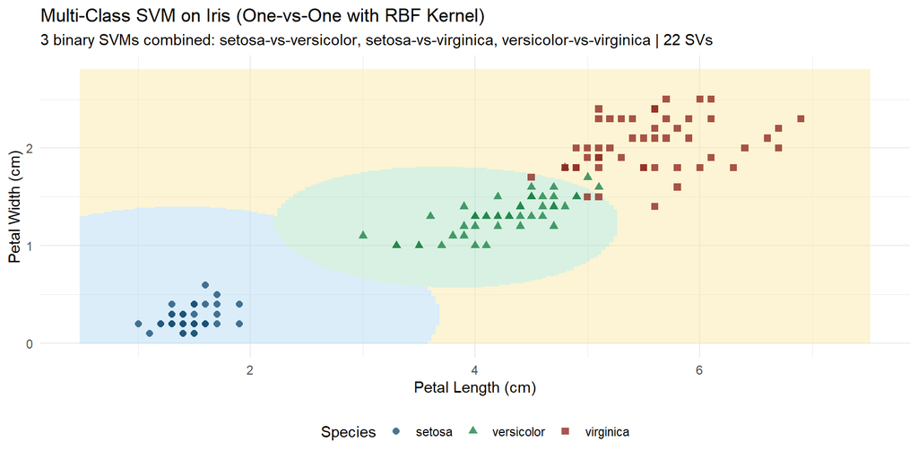

```r
set.seed(MASTER_SEED + 10)

iris_3class <- svm(Species ~ Petal.Length + Petal.Width, data = iris,
                   kernel = "radial", cost = 5, gamma = 1, scale = TRUE)

grid_3c <- expand.grid(
  Petal.Length = seq(0.5, 7.5, length.out = 200),
  Petal.Width  = seq(0, 2.8, length.out = 200)
)
grid_3c$pred <- predict(iris_3class, grid_3c)

ggplot() +
  geom_tile(data = grid_3c,
            aes(x = Petal.Length, y = Petal.Width, fill = pred), alpha = 0.45) +
  geom_point(data = iris,
             aes(x = Petal.Length, y = Petal.Width, color = Species, shape = Species),
             size = 2, alpha = 0.8) +
  scale_fill_manual(values = palette_iris, guide = "none") +
  scale_color_manual(values = point_colors) +
  labs(
    title = "Multi-Class SVM on Iris (One-vs-One with RBF Kernel)",
    subtitle = sprintf("3 binary SVMs combined: setosa-vs-versicolor, setosa-vs-virginica, versicolor-vs-virginica | %d SVs",
                       nrow(iris_3class$SV)),
    x = "Petal Length (cm)", y = "Petal Width (cm)"
  ) +
  theme_minimal() +
  theme(legend.position = "bottom")
```

# Knowledge Check

**Question 1:** In your own words, what is a support vector and why is it called that?**

**Answer:** A support vector is one of the training data points that sits exactly on the margin boundary (or inside/beyond it in the soft-margin case). They are called “support” vectors because they literally *hold up* the margin — if you removed any non-support-vector point, the decision boundary would not change at all. The entire SVM model is defined by just these few critical points.

**Question 2:** What happens if you set C to an extremely large value? What about an extremely small value?**

**Answer:** **Very large C** means the SVM tries very hard to classify every single training point correctly. The margin becomes narrow and the boundary tightly wraps around the data — this leads to **overfitting**. **Very small C** means the SVM is very tolerant of misclassifications. The margin becomes wide and the boundary is smooth and simple — this can lead to **underfitting**. The optimal C balances these extremes.

**Question 3:** Why must you scale your features before training an SVM, but not before training a Decision Tree?**

**Answer:** SVMs compute distances between data points (via the kernel function). If Feature A ranges from 0 to 1 and Feature B ranges from 0 to 100,000, then Feature B will dominate all distance calculations, making Feature A effectively invisible. Decision Trees, on the other hand, only compare a feature against thresholds one at a time — they never compute distances between features, so scaling is irrelevant.

**Question 4:** Explain the kernel trick as if you were talking to someone who has never studied math.**

**Answer:** Imagine you have red and blue coins mixed together on a table. You need to separate them with a straight ruler, but they’re too tangled up. The kernel trick is like picking up the table and shaking it so the coins jump into the air — in 3D, the red coins fly higher than the blue ones, and now you can slide a flat piece of glass between them. The kernel does this “lifting” mathematically without actually computing the 3D positions — it just needs to know how far apart the coins are in the new arrangement.

**Question 5:** You train an SVM on a dataset and notice that 95% of your training points are support vectors. What does this tell you?**

**Answer:** If nearly all points are support vectors, it typically means: (1) C is too small — the model is too lenient and isn’t creating a meaningful margin, or (2) the kernel is not appropriate (e.g., using a linear kernel on highly non-linear data). In either case, the SVM is essentially memorizing most of the training data rather than finding a clean separating boundary. Try increasing C, switching to a different kernel, or tuning $\gamma$.

**Question 6:** When would you choose an SVM over a Random Forest, and vice versa?**

**Answer:** Choose **SVM** when: you have a small-to-medium dataset (< 10K rows), the boundary is complex and non-linear, you have high-dimensional data (e.g., gene expression data where features outnumber samples), or you need a sparse model (only support vectors are stored). Choose **Random Forest** when: you have a large dataset, you want a strong baseline with minimal tuning, you need feature importance rankings, or you need interpretable probability estimates.

# Summary

| Concept | Key Idea | R Implementation |
| --- | --- | --- |
| **Hyperplane** | The boundary that separates classes | `svm(..., kernel = "linear")` |
| **Margin** | Gap between the closest points of each class; SVM maximizes this | Controlled by the `cost` (C) parameter |
| **Support Vectors** | The critical points on the margin that define the boundary | Accessible via `model$SV` and `model$index` |
| **C Parameter** | Trade-off dial: small C = wide margin (simple), large C = narrow margin (complex) | `cost = 1` (default) |
| **Kernel Trick** | Transform data into higher dimensions so a linear separator works | `kernel = "radial"` / `"polynomial"` / `"linear"` |
| **Gamma ($\gamma$)** | Controls how far each point’s influence reaches in the RBF kernel | `gamma = 0.1` |
| **Feature Scaling** | Always standardize features before SVM | `scale = TRUE` (default in `e1071`) |
| **SVR** | SVM for regression: fit an $\varepsilon$-tube around the data | `svm(..., type = "eps-regression")` |
| **Multi-class** | One-vs-One strategy: train $k(k-1)/2$ binary SVMs | Automatic in `e1071::svm()` |
| **Hyperparameter Tuning** | Use cross-validation to find optimal C and $\gamma$ | `tune(svm, ...)` or `caret::train()` |

**The Big Picture:** SVMs approach classification from a fundamentally different angle than trees: instead of asking questions about features, they find the *widest possible gap* between classes. The kernel trick lets them handle complex, non-linear data without explicitly computing high-dimensional transformations. Combined with careful tuning of C and $\gamma$, SVMs remain one of the most powerful algorithms for small-to-medium datasets with complex boundaries.

# References

[1] scikit-learn developers, “1.4. Support Vector Machines,” *scikit-learn 1.8.0 documentation*, 2026. [Online]. Available: https://scikit-learn.org/stable/modules/svm.html

[2] Wikipedia contributors, “Support vector machine,” *Wikipedia, The Free Encyclopedia*, 2026. [Online]. Available: https://en.wikipedia.org/wiki/Support_vector_machine

[3] A. Géron, *Hands-On Machine Learning with Scikit-Learn, Keras, and TensorFlow*, 2nd ed. Sebastopol, CA: O’Reilly Media, 2019, ch. 5.

[4] B. C. Boehmke and B. M. Greenwell, *Hands-On Machine Learning with R*. Boca Raton, FL: CRC Press, 2020, ch. 14. [Online]. Available: https://bradleyboehmke.github.io/HOML/

[5] C. Cortes and V. Vapnik, “Support-vector networks,” *Machine Learning*, vol. 20, no. 3, pp. 273–297, 1995.

[6] C. Chang and C. Lin, “LIBSVM: A Library for Support Vector Machines,” *ACM Transactions on Intelligent Systems and Technology*, vol. 2, no. 3, pp. 1–27, 2011.

[7] D. Meyer, E. Dimitriadou, K. Hornik, A. Weingessel, and F. Leisch, “e1071: Misc Functions of the Department of Statistics, Probability Theory Group,” R package, 2023. [Online]. Available: https://CRAN.R-project.org/package=e1071

[8] A. Karatzoglou, A. Smola, K. Hornik, and A. Zeileis, “kernlab — An S4 Package for Kernel Methods in R,” *Journal of Statistical Software*, vol. 11, no. 9, pp. 1–20, 2004.

[9] Z. Huang, “seedhash: Deterministic Seed Generation from String Inputs Using MD5 Hashing,” R package, 2026. [Online]. Available: https://github.com/melhzy/seedhash